# Hyperparameter Tuning using Logarithmic Marginal Likelihood

This notebook explains the theory behind the Marginal Likelihood (LM) functional and how it can be used to find the optimal hyperparameters. **Part 1** explains the theory if the functional while **Part 2** provides an example implemented using the *sklearn* package to show how good hyperparameters influence the predictive quality of a GP. After that the functional itself is computed and visualized in accordance to the underlying process. **Part 3** will show how the size of the training set influences the functionals behaviour.

## Part 1 - Hyperparameter Optimization

Before we talk about how to tune your hyperparameters we have to take a step back and take a look at how we set what our hyperparameters are in the first place. To do so we briefly talk about *Model Selection*. *Model Selection* includes all aspects of the model including the choice of the covariance and its hyperparameters. This will help to improve predictions and makes interpretation by the user possible. The prolbem is: A multitude of possible covariance function families exist and each of them have numerous hyperparameters. Different hyperparameters have to be compared within a family and a comparison across families has to be made. From this it is clear that the model selection process is open ended but Literatur provides three general principles for model selection

1. Compute probability of the model given the data
2. Estimate the generalization error (error on unseen test samples)
3. Bound the generalization error

Note: training error is usually a poor proxy of the generalization error due to overfitting (model learning the data / noise in the training set).  
The following two sections present different approaches to "solve" the model selection process. Afterwards a section dedicated to model selection for GP Regression follows. The sections involve a bit of probability theory and I assume that you are familiar with terms like marginalisation, Bayes'rule, likelihood and other terms from the field of probability theory.

### Bayesian Model Selection

This will be a short outline of the main ideas in Bayesian model selection.  
A common way to approach the problem is a hierarchical specification of the models. At level 1 we look at the parameters **w** which can be the parameters in a linear model. The second level are the hyperparameters $\theta$ which control the distribution of the parameters (e.g. weight decay in a neural network) and the highest level contains a discrete set of possible model structures $\mathcal{H}_i$. Inference takes place at one level at a time applying general rules of probability theory [MacKay, D. J. C. (1992b). Bayesian Interpolation. Neural Computation].

#### Level 1

At this level we look at the posterior over the parameters **w** given by Bayes'rule

\begin{equation*} p(\textbf{w} | y, X, \textbf{$\theta$}, \mathcal{H}_i) = \frac{ p(\textbf{y} | X, \textbf{w}, \mathcal{H}_i) p(\textbf{w} | \textbf{$\theta$}, \mathcal{H}_i) }{ p(\textbf{y} | X, \textbf{$\theta$}, \mathcal{H}_i ) } \end{equation*}

where $p(\textbf{y} | X, \textbf{w}, \mathcal{H}_i)$ is the likelihood of the observations given the input space, the parameters **w** and the selected model $\mathcal{H}_i$. The term $p(\textbf{w} | \textbf{$\theta$}, \mathcal{H}_i)$ represents the parameter prior given the selected model and its hyperparameters. It encodes the probability distribution of our knowledge about the parameters prior seeing the data. If we have specific knowledge this probability distribuition will be narrow. The posterior $p(\textbf{w} | y, X, \textbf{$\theta$}, \mathcal{H}_i)$ then combines all the information we have through the observation (using the likelihood term $p(\textbf{y} | X, \textbf{w}, \mathcal{H}_i)$) and our prior beliefs about the model and its parameters. It is normalized the so called marginal likelihood (also called *evidence*) Note that the *evidence* is independent of the parameters since they get marginalized. It is given by

\begin{equation*} p(\textbf{y} | X, \textbf{$\theta$}, \mathcal{H}_i ) = \int p(\textbf{y} | X, \textbf{w}, \mathcal{H}_i) p(\textbf{w} | \textbf{$\theta$}, \mathcal{H}_i) d\textbf{w} \end{equation*}

#### Level 2

Now it is possible to derive a new posterior for the hyperparameters $\textbf{$\theta$}$ using the marginal likelihood from level 1.

\begin{equation*} p( \textbf{$\theta$} | y, X, \mathcal{H}_i) = \frac{ p(\textbf{y} | X, \textbf{$\theta$}, \mathcal{H}_i) p(\textbf{$\theta$} | \mathcal{H}_i) }{ p(\textbf{y} | X, \mathcal{H}_i ) } \end{equation*}

where $p(\textbf{$\theta$} | \mathcal{H}_i)$ is the so called *hyper prior* (prior for the hyperparameters which control the parameter distribution). The normalizing constant is given analogously to level 1 but marginalizes of the hyperparameters $\textbf{$\theta$}$

\begin{equation*} p(\textbf{y} | X, \mathcal{H}_i ) = \int p(\textbf{y} | X, \textbf{$\theta$}, \mathcal{H}_i) p(\textbf{$\theta$} | \mathcal{H}_i) d\textbf{$\theta$} \end{equation*}

#### Level 3

On the highest level in the model selection process the posterior for the model is computed

\begin{equation*} p( \mathcal{H}_i | y, X, ) = \frac{ p(\textbf{y} | X, \mathcal{H}_i) p(\ \mathcal{H}_i ) }{ p(\textbf{y} | X) } \end{equation*}

where $p( \textbf{y} | X) = \sum_{i}^{} p(\textbf{y} | X, \mathcal{H}_i)p(\ \mathcal{H}_i )$.

Its worth noticing that this kind of model selecting requires the user to compute several integral which may not be analytically tractable. One can therefore use Markov Chain Monte Carlo (MCMC) methods. In practice the calculation of the normalizing constant of level 2 can be difficult which then affects solving the equation for $p( \textbf{$\theta$} | y, X, \mathcal{H}_i)$.  
To avoid solving the equation for the hyperprior one may approximates $p(\textbf{y} | X, \textbf{$\theta$}, \mathcal{H}_i )$ w.r.t. the hyperparameters $\textbf{$\theta$}$, known as type II maximum likelihood (ML-II). This approximation comes at the risk of inducing the possibility of overfitting into the selection process. This risk even increases when we have a high dimensional hyperparameter space.  
Its worth noting that the marginal likelihood, e.g. in the equation for the parameter (**w**) posterior, automatically incorpoartes a trade-off between model fit and model complexity which makes is so valuable.

### Cross-validation

Cross-validation (CV) is a well known and widely used technique for model selection. The idea is to split the available data set into two disjoint sets. One of which is used for training the model, the other one for validation. The models performance on the validation set is used as estimate for the generalization error. In practice only a fraction of data is used in validation which may lead to performance with large variance.  
To minimize the variance in the generalization *k-fold cross-validation* can be used. In that case the data is split into $\textbf{k}$ disjoint, equally sized subsets and validation is done on a single subset while training uses the union of the remaining $\textbf{k-1}$ subsets. The whole procedure is repeated $\textbf{k}$ times, each time with a different subset for validation. Thus a large fraction of the data used for training. This comes at a price: $\textbf{k}$ models must be trained Typical $\textbf{k} = [3, ..., 10]$.

### Model Selection for GP Regression

#### Marginal Likelihood

As mentioned above, Bayesian principles require analytical intractable computations (integrals over parameter space) but GPs are an exception. Since GPs are non-parametric models it is not immediately clear what the parameters of a model are. In the section before we called **w** in the level 1 inference. Recap that the posterior of the parameters was given by \begin{equation*} p(\textbf{w} | y, X, \textbf{$\theta$}, \mathcal{H}_i) = \frac{ p(\textbf{y} | X, \textbf{w}, \mathcal{H}_i) p(\textbf{w} | \textbf{$\theta$}, \mathcal{H}_i) }{ p(\textbf{y} | X, \textbf{$\theta$}, \mathcal{H}_i ) } \end{equation*}

and the evidence defined as

\begin{equation*} p(\textbf{y} | X, \textbf{$\theta$}, \mathcal{H}_i ) = \int p(\textbf{y} | X, \textbf{w}, \mathcal{H}_i) p(\textbf{w} | \textbf{$\theta$}, \mathcal{H}_i) d\textbf{w} \end{equation*}

which can be expressed as  
\begin{equation*} \log p(\textbf{y} | X, \textbf{$\theta$}) = \frac{1}{2} \textbf{y}^T K_{y}^{-1} \textbf{y} - \frac{1}{2} \log |K_y| - \frac{n}{2} \log 2 \pi \end{equation*} where $K_y = K_f + \sigma_n^2 I$ is the covariance matrix for noisy targets $\textbf{y}$

This equation contains three terms which can be interpreted. The first term $\textbf{y}^T K_{y}^{-1} \textbf{y}$ contains the observed data is used to control the data fit. The second term $\log |K_y|$ is a complexity penalty since it depends on the covariance function. The last term is a normalization constant.

Since $\log p(\textbf{y} | X, \textbf{$\theta$})$ is conditioned on the hyperparameters $\textbf{$\theta$}$ it can be maximized with respect to it. This can be achieved by using the partial derivatives of $\log p(\textbf{y} | X, \textbf{$\theta$})$ w.r.t. every hyperparameter $\theta_j$. The partial derivatives are defined as

\begin{equation*} \frac{\partial}{\partial \theta_j} \log p(\textbf{y} | X, \textbf{$\theta$}) = \frac{1}{2} \textbf{y}^T K^{-1} \frac{\partial K}{\partial \theta_j} K^{-1} \textbf{y} - \frac{1}{2} \text{tr} \big( K^{-1} \frac{\partial K}{\partial \theta_j} \big) \end{equation*}

The complexity of solving this equation is $\mathcal{O} (n^2)$ once $K^{-1}$ is known. Therefore gradient based optimizers can be used.

```python
import utils
import gpflow
import numpy as np
import matplotlib
import math
import tensorflow as tf
import matplotlib.pyplot as plt
%matplotlib inline
# Launch the graph in a session.
sess = tf.Session()

from matplotlib.colors import LogNorm
from sklearn.gaussian_process import GaussianProcessRegressor
from sklearn.gaussian_process.kernels import RBF, Matern

from matplotlib.ticker import MaxNLocator
from matplotlib.colors import BoundaryNorm
```

```python
fontsize_label = 24
fontsize_legend = 20
fontsize_ticks = 20
linewidth = 2.4
markeredgewidth = 2
markersize = 7
matplotlib.rcParams['figure.figsize'] = (16, 8)
```

```python
# Parameters
lengthscale = 0.9
sigma_f = 1.
sigma_n = 0.
N_scales = 40
f = 0.5
num_Levels = 30
# Generate data
np.random.seed(9)
# Set some parameters
f = 0.5
N = 40
sigma_n = 0.0
# Build data sets
X = np.linspace(-3., 3., 100).reshape(100, 1)
Y_true = np.sin(X * (2 * math.pi * f))
X_sample = np.random.uniform(-3.,3.,(N,1))
Y_sample = np.sin(X_sample * (2 * math.pi * f))
```

```
GaussianProcessRegressor(alpha=1e-09, copy_X_train=True,
             kernel=1**2 * RBF(length_scale=0.9), n_restarts_optimizer=10,
             normalize_y=False, optimizer='fmin_l_bfgs_b',
             random_state=None)
```

```
6.15**2 * RBF(length_scale=1.1)
```

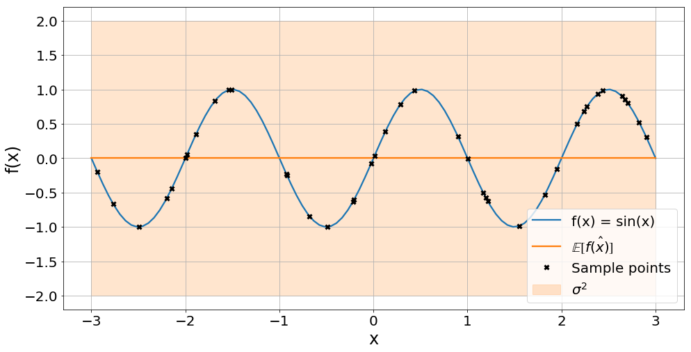

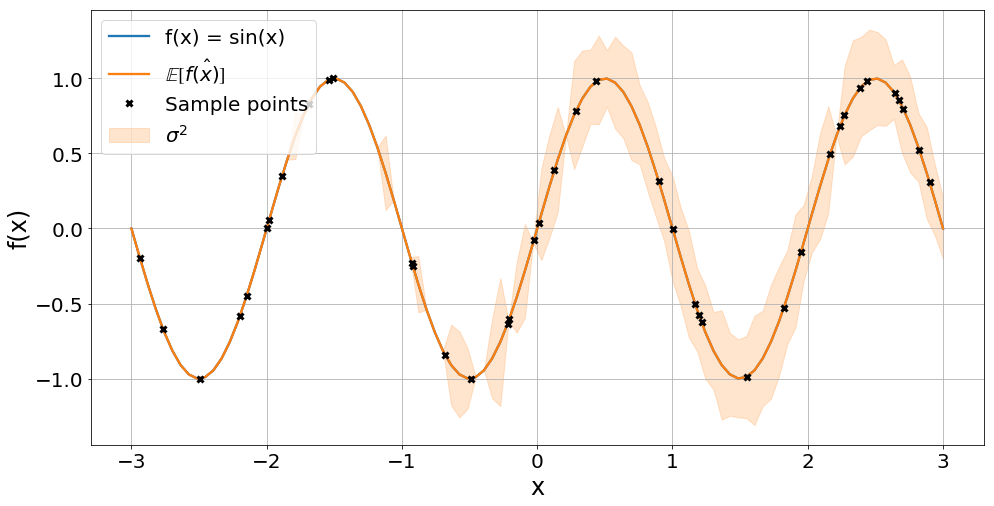

```python
#GP
k = sigma_f * RBF(length_scale=lengthscale, length_scale_bounds=(1e-2, 1e3))
#k = sigma_f * Matern(length_scale=lengthscale, length_scale_bounds=(1e-05, 100000.0), nu=2.5)
#alpha = Konstant to avoid numerical problems by ensuring a positiv semi definit matrix
gp = GaussianProcessRegressor(kernel=k, alpha=0.000000001, n_restarts_optimizer=10)
print(gp)
# Predict with unfitted kernel
mean, stddev = gp.predict(X, return_std=True)
mean = mean.reshape(mean.shape[0], 1)
stddev = stddev.reshape(stddev.shape[0], 1)
fig = utils.plot2D(mean, stddev, X, [X, Y_true, 'f(x) = sin(x)'], [X, mean, '$\mathbb{E[}\hat{f(x)}\mathbb{]}$'],
             [X_sample, Y_sample, 'Sample points', 'kx'])
gp = gp.fit(X_sample, Y_sample)
print(gp.kernel_)

# Predict with fitted kernel
mean, stddev = gp.predict(X, return_std=True)
mean = mean.reshape(mean.shape[0], 1)

stddev = stddev.reshape(stddev.shape[0], 1)
fig = utils.plot2D(mean, stddev, X, [X, Y_true, 'f(x) = sin(x)'], [X, mean, '$\mathbb{E[}\hat{f(x)}\mathbb{]}$'],
             [X_sample, Y_sample, 'Sample points', 'kx'])
```

According to http://www.gaussianprocess.org/gpml/ there is no guarantee the LML does find the global optimum since it is not a convex function (https://drafts.distill.pub/gp/). In fact there can be multiple local maxima which for simple covariance functions are not a severe problem. But if there are multiple maxima they correspond to different interpretations of the data. The number of local maxima can be reduced if the number of training samples is increased but often results in huge plateaus as seen in the following example.

```python
# Calculate LML according to the fitting process
#  numpy.logspace(start, stop, num=50, endpoint=True, base=10.0, dtype=None)
theta0 = np.logspace(-0, 3, N_scales) # lengthscale
theta1 = np.logspace(-1, 1, N_scales) # sigma_f
Theta0, Theta1 = np.meshgrid(theta0, theta1) # (N_scales, N_scales)
LML = [[gp.log_marginal_likelihood(np.log([Theta0[i, j], Theta1[i, j]]))
        for i in range(Theta0.shape[0])] for j in range(Theta0.shape[1])]
LML = np.array(LML)

print("init: gp.kernel: " + str(gp.kernel))
print("optimized: gp.kernel_="+str(gp.kernel_))
print("gp.kernel_.theta="+str(gp.kernel_.theta))
print("np.exp(gp.kernel_.theta)="+str(np.exp(gp.kernel_.theta)))
print("np.exp(gp.kernel_.theta)[0], np.exp(gp.kernel_.theta)[1]: " + str(np.exp(gp.kernel_.theta)[0]) +', '
      + str(np.exp(gp.kernel_.theta)[1]))
print("sqrt(np.exp(gp.kernel_.theta)[0])="+str(np.sqrt(np.exp(gp.kernel_.theta)[0])))
```

```
init: gp.kernel: 1**2 * RBF(length_scale=0.9)
optimized: gp.kernel_=6.15**2 * RBF(length_scale=1.1)
gp.kernel_.theta=[3.63216061 0.0966649 ]
np.exp(gp.kernel_.theta)=[37.7943873   1.10149121]
np.exp(gp.kernel_.theta)[0], np.exp(gp.kernel_.theta)[1]: 37.79438729650526, 1.1014912056234136
sqrt(np.exp(gp.kernel_.theta)[0])=6.147713989484649
```

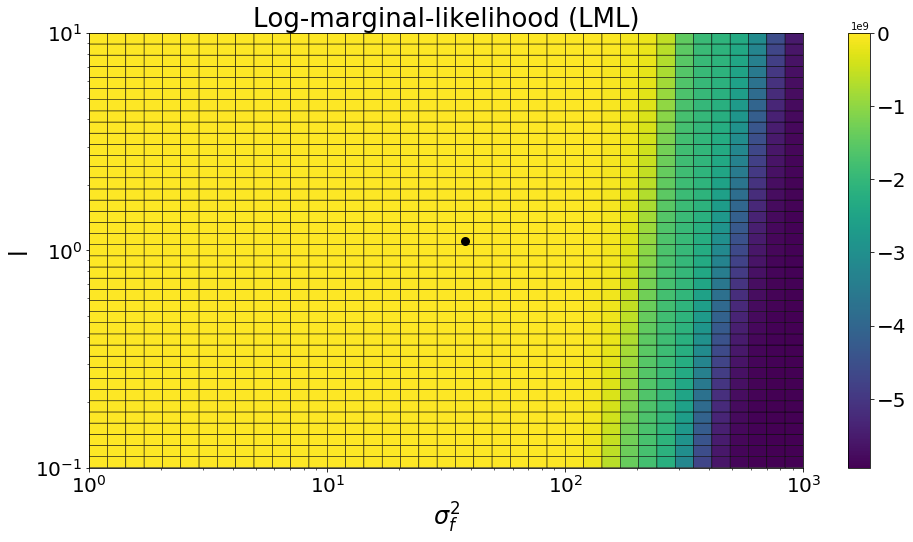

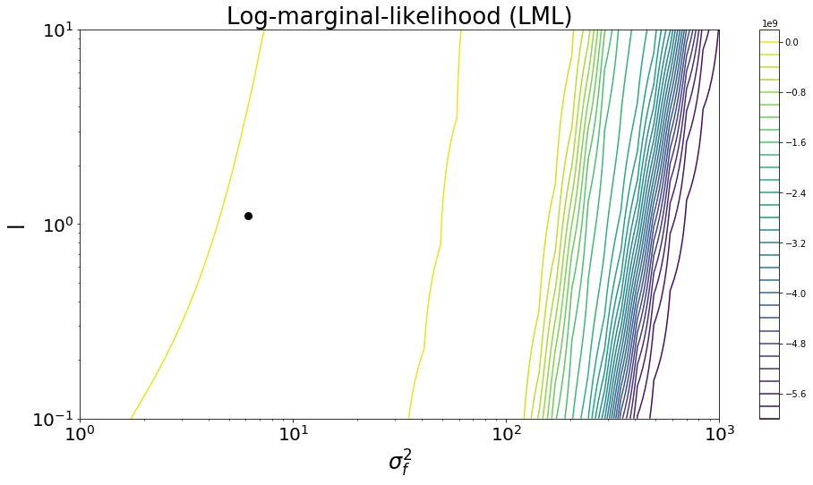

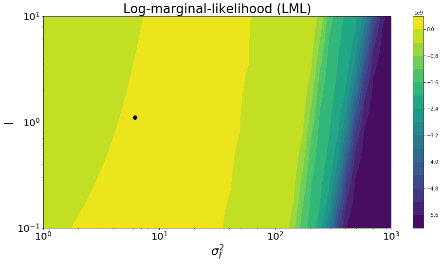

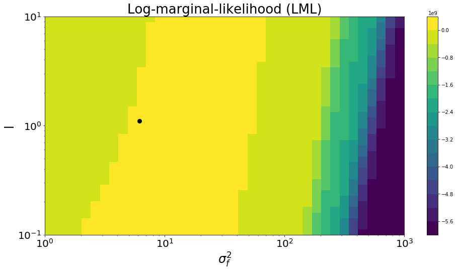

```python
## Plot LML according to the fitting process
plt.figure()
plt.plot(np.exp(gp.kernel_.theta)[0], np.exp(gp.kernel_.theta)[1], 'ko', zorder=10, markersize=markersize,
         markeredgewidth=markeredgewidth)
plt.pcolor(Theta0, Theta1, LML, edgecolors='k', linewidths=.5)
plt.xscale("log")
plt.yscale("log")
cbar = plt.colorbar()
cbar.ax.tick_params(labelsize=fontsize_ticks)
plt.ylabel("l", fontsize=fontsize_label)
plt.xlabel("$\sigma_f^2$", fontsize=fontsize_label)
plt.title("Log-marginal-likelihood (LML)", fontsize=fontsize_label+2)
plt.xticks(fontsize=fontsize_ticks)
plt.yticks(fontsize=fontsize_ticks)
plt.show()

# Same as contour plot
plt.figure()
plt.plot(np.sqrt(np.exp(gp.kernel_.theta)[0]), np.exp(gp.kernel_.theta)[1], 'ko', zorder=10, markersize=markersize,
         markeredgewidth=markeredgewidth)
plt.contour(Theta0, Theta1, LML, levels=num_Levels)
plt.colorbar()
plt.xscale("log")
plt.yscale("log")
plt.ylabel("l", fontsize=fontsize_label)
plt.xlabel("$\sigma_f^2$", fontsize=fontsize_label)
plt.title("Log-marginal-likelihood (LML)", fontsize=fontsize_label+2)
plt.xticks(fontsize=fontsize_ticks)
plt.yticks(fontsize=fontsize_ticks)
plt.show()

# Same as contourf
fig = plt.figure()
plt.plot(np.sqrt(np.exp(gp.kernel_.theta)[0]), np.exp(gp.kernel_.theta)[1], 'ko', zorder=10, markersize=markersize,
         markeredgewidth=markeredgewidth)
levels = MaxNLocator(nbins=15).tick_values(LML.min(), LML.max())
plt.contourf(Theta0, Theta1, LML, levels=levels)
plt.colorbar()
plt.xscale("log")
plt.yscale("log")
plt.ylabel("l", fontsize=fontsize_label)
plt.xlabel("$\sigma_f^2$", fontsize=fontsize_label)
plt.title("Log-marginal-likelihood (LML)", fontsize=fontsize_label+2)
plt.xticks(fontsize=fontsize_ticks)
plt.yticks(fontsize=fontsize_ticks)
plt.show()

fig.savefig("LML_contourf2D.pdf", bbox_inches='tight')

# Same as contourf
plt.figure()
plt.plot(np.sqrt(np.exp(gp.kernel_.theta)[0]), np.exp(gp.kernel_.theta)[1], 'ko', zorder=10, markersize=markersize,
         markeredgewidth=markeredgewidth)
levels = MaxNLocator(nbins=15).tick_values(LML.min(), LML.max())
cmap = plt.get_cmap('viridis')
norm = BoundaryNorm(levels, ncolors=cmap.N, clip=True)
plt.pcolormesh(Theta0, Theta1, LML, norm=norm)
plt.colorbar()
plt.xscale("log")
plt.yscale("log")
plt.ylabel("l", fontsize=fontsize_label)
plt.xlabel("$\sigma_f^2$", fontsize=fontsize_label)
plt.title("Log-marginal-likelihood (LML)", fontsize=fontsize_label+2)
plt.xticks(fontsize=fontsize_ticks)
plt.yticks(fontsize=fontsize_ticks)
plt.show()
```

## Part 3 - Size of the training set

```python
# Create data set
# sigma_n = 0.0
N = 2000
num_Functions = 1
# Build input space
X = np.linspace(0., 5., N).reshape(N, 1)
```

```
WARNING:matplotlib.legend:No handles with labels found to put in legend.
```

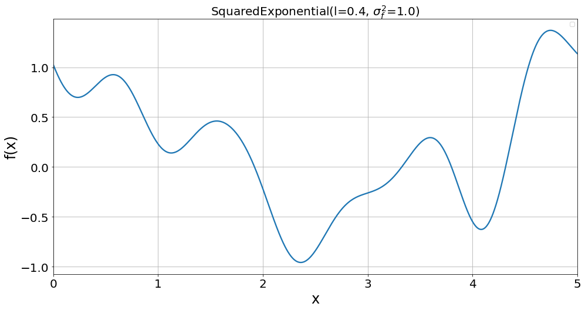

```python
np.random.seed(9)
# Draw random function form kernel
num_Functions = 1
lengthscale = 0.4
sigma_f = 1.0
k = gpflow.kernels.RBF(1, lengthscales=lengthscale)
Y_drawn = utils.drawRandomFunction(k, X, num_Functions)
utils.plotRandomFunction(X, [Y_drawn], [k], [None])
```

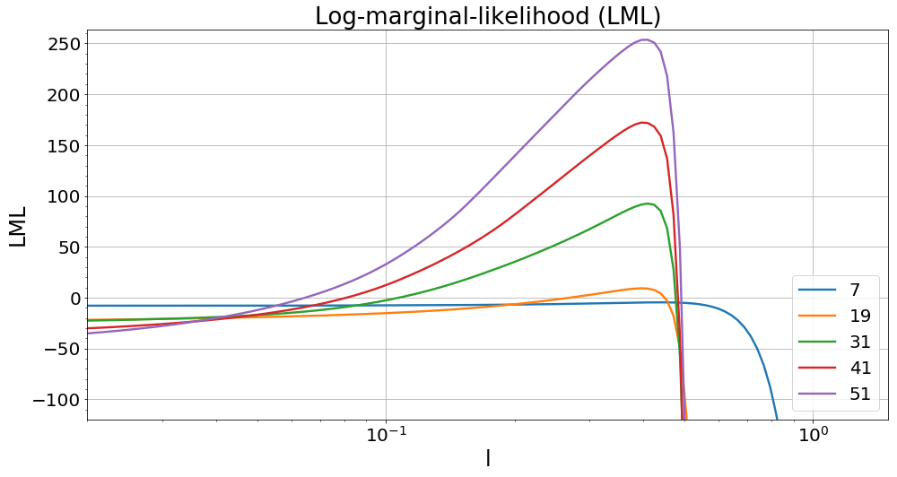

```
0.41026581058271927
```

```python
np.random.seed(9)
max_value = -10000000000000000000000000
sample_size = np.array([7,19,31,41, 51])
k = RBF(length_scale=lengthscale, length_scale_bounds=(1e-2, 1e3))
N_scales = 200
#  numpy.logspace(start, stop, num=50, endpoint=True, base=10.0, dtype=None)
theta0 = np.logspace(-2, 1, N_scales) # lengthscale
fig = plt.figure()
for size in sample_size:
    # Create data
    index = np.random.randint(0, high=N, size=size)
    X_sample = X[index]
    Y_sample = Y_drawn[index]
    gp = GaussianProcessRegressor(kernel=k, alpha=0.000000001, n_restarts_optimizer=10).fit(X_sample, Y_sample)

    # Calculate LML
    LML = [gp.log_marginal_likelihood(np.array([np.log(theta0[i])])) for i in range(theta0.shape[0])]
    LML = np.array(LML).reshape(N_scales, 1)
    if np.max(LML) > max_value:
        max_value = np.max(LML)


    # Plot
    plt.plot(theta0, LML, linewidth=linewidth, label=str(size))
#plt.axvline(theta0[np.argmax(LML)], label="max={:10.6}".format(str(theta0[np.argmax(LML)])), color="k")
plt.xscale("log")
plt.xlabel("l", fontsize=fontsize_label)
plt.ylim(bottom=-120.0, top=max_value+10)
plt.xlim(left=0.02, right=1.5)
plt.ylabel("LML", fontsize=fontsize_label)
plt.title("Log-marginal-likelihood (LML)", fontsize=fontsize_label+2)
plt.xticks(fontsize=fontsize_ticks)
plt.yticks(fontsize=fontsize_ticks)
plt.minorticks_on()
plt.grid()
plt.legend(prop={'size': fontsize_legend}, loc=4)
plt.show()
fig.savefig("LML_peakiness.pdf", bbox_inches='tight')
print(theta0[np.argmax(LML)])
```